# Statistical Inferences Course Work - Part 1: Simulation Exercise

Ts. Nurul Haszeli Ahmad

11/22/2020

## Overview

This is a simulation exercise done to comply with the requirement to complete the Statistical Inferences course. In this simulation exercise, we will investigate the exponential distribution in R and compare it with the Central Limit Theorem. The exponential distribution can be simulated in R with rexp(n, lambda) where lambda is the rate parameter. The mean of the exponential distribution is 1/lambda, and the standard deviation is also 1/lambda. We will investigate the distribution of averages of 40 exponentials and a total of a thousand simulations.

## Initial setting

First, we set our seed and parameters based on the given set of data within this course work.

```r
#set the seed
set.seed(1976)

#Set lambda = 0.2 for all of the simulations.
lambda <- 0.2

#Distribution of averages of 40 exponentials.
total_exponentials <- 40

#Total simulations is 1000
total_simulation <- 1000
```

## Execute the simulation and plot into histogram and distribution

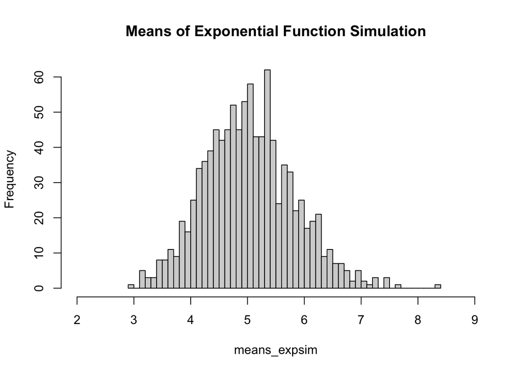

```r
# run simulations
running_sim <- replicate(total_simulation, rexp(total_exponentials,lambda))

# Calculate means of exponential simulations
means_expsim <- apply(running_sim,2, mean)

# Plot means histogram
hist(means_expsim, breaks = total_exponentials, xlim = c(2,9),
     main = "Means of Exponential Function Simulation")
```

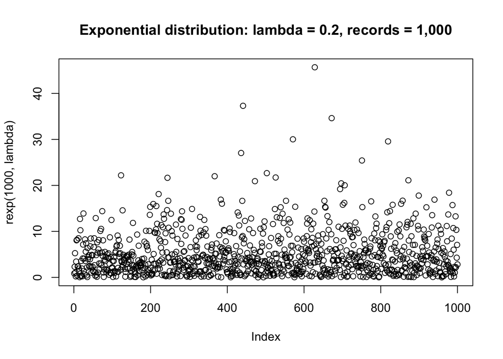

```r
# Exponential distribution can be simulated in R with rexp(n, lambda)
plot(rexp(1000,lambda),
     main="Exponential distribution: lambda = 0.2, records = 1,000")
```

**Note**: The last plot does a quick plot to familiarize with the rexp. It is easy to see from plot that the majority of the values fall below 10, approximately around 5. There are no non-zero values so expect a mean around 5.

## Question

### Question 1: Sample Mean vs. Theoretical Mean

The exponential distribution mean is 1/lambda. For this simulation, lambda is 0.2. The theoretical mean should be 5 (i.e., 1 / 0.2).

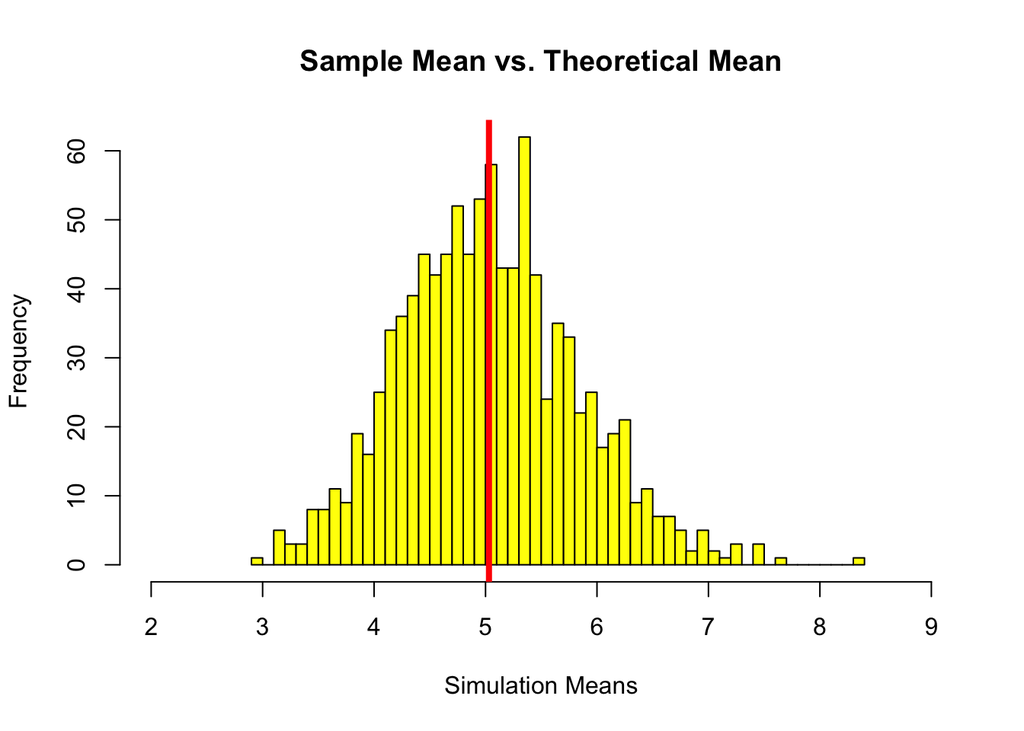

```r
# plot histogram of the sample means
hist(means_expsim, main = "Sample Mean vs. Theoretical Mean", xlim =  c(2,9),
     breaks = total_exponentials, xlab = "Simulation Means", col = "yellow")

# plot vertical blue line at mean of samples
abline(v = mean(means_expsim), lwd = "4", col = "red")
```

```r
# calculate the mean of our samples
mean(means_expsim)
```

```
## [1] 5.030864
```

### Question 2: Sample Variance vs. Theoretical Variance

The standard deviation of the exponential distribution is (1/lambda) / sqrt(n). We will compare this to our simulations.

```r
# theoretical variance vs. simulated variance
print(paste ("Theoretical variance is: ", round( (1/lambda)^2/total_exponentials, 3)))
```

```
## [1] "Theoretical variance is:  0.625"
```

```r
print(paste("Actual variance is: ", round( var(means_expsim),3)))
```

```
## [1] "Actual variance is:  0.625"
```

**Result**: Based on the above result, both variances are close to each other indicating that the theoretical can be considered giving a true value of an actual result.

### Question 3: Distribution

The following simulate whether the exponential distribution is approximately normal. Due to the Central Limit Theorem, the means of the sample simulations should follow a normal distribution.

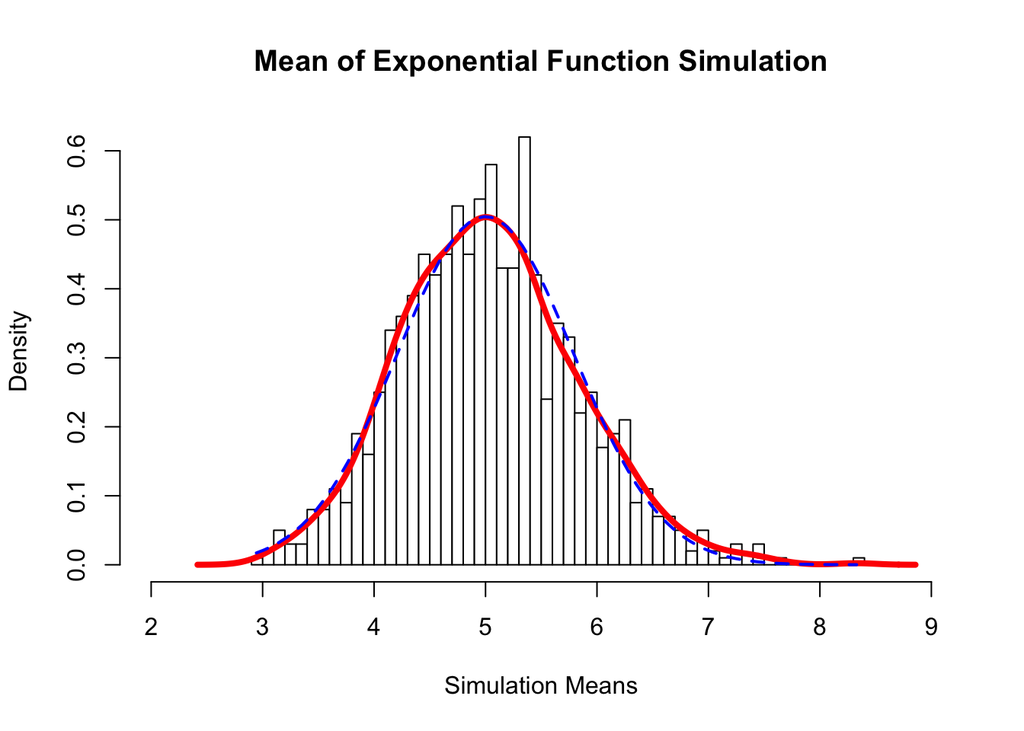

```r
# Histogram with distribution curve included
hist(means_expsim, prob=TRUE, main = "Mean of Exponential Function Simulation",
     breaks = 40, xlim = c(2,9), xlab = "Simulation Means", col = "white")
lines(density(means_expsim), lwd=4, col="red")

# Normal distribution line
x <- seq(min(means_expsim), max(means_expsim), length = 2*total_exponentials)
y <- dnorm(x, mean = 1/lambda, sd = sqrt(((1/lambda)/sqrt(total_exponentials))^2))
lines(x,y, pch = 20, lwd = 2, lty = 2, col="blue")
```